# Dimension Reduction

## 5. Power of SVD and PCA and their working as data compression technique

#### 5.1.1 Loading dataset and plotting Image

```r
load("./data/face.rda")

faceData[1:10,1:10]
```

```
##       [,1] [,2] [,3] [,4] [,5] [,6] [,7] [,8] [,9] [,10]
##  [1,]   38   32   33   47   35   32   37   72   75   100
##  [2,]   39   30   57   44   35   41   80  121  143   151
##  [3,]   34   34   33   43   58   50  126  132  143   159
##  [4,]   27   24   30   65   99  130  129  146  162   173
##  [5,]   29   28   33   69  118  139  148  159  165   176
##  [6,]   33   28   38   80  112  139  156  161  170   174
##  [7,]   23   29   41   76  103  132  159  168  174   178
##  [8,]   26   29   34   65  104  134  153  165  173   180
##  [9,]   23   22   31   72  100  134  149  163  175   183
## [10,]   26   25   32   53  112  132  152  165  175   183
```

```r
dim(faceData)
```

```
## [1] 32 32
```

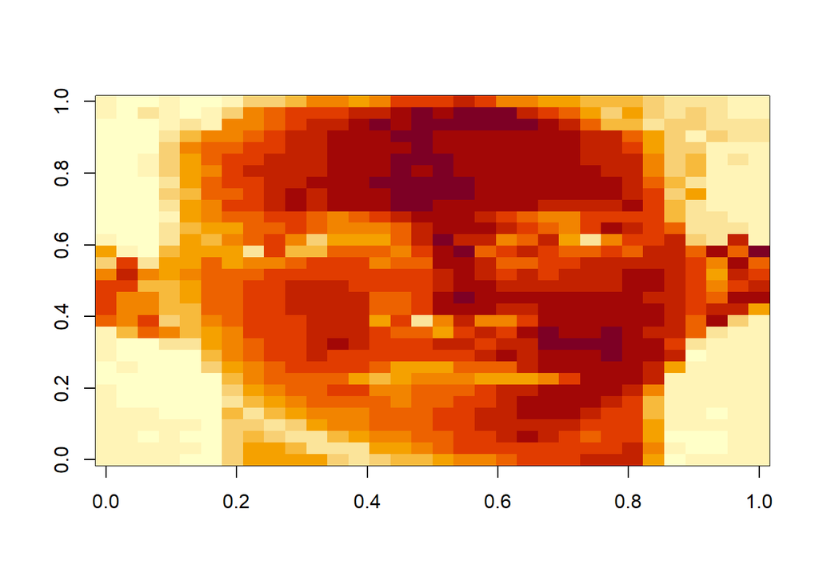

```r
image(t(faceData)[,nrow(faceData):1])
```

#### 5.1.2 Apply svd()

```r
svd_face <- svd(scale(faceData))
```

#### 5.1.3 Variance Explained Plot

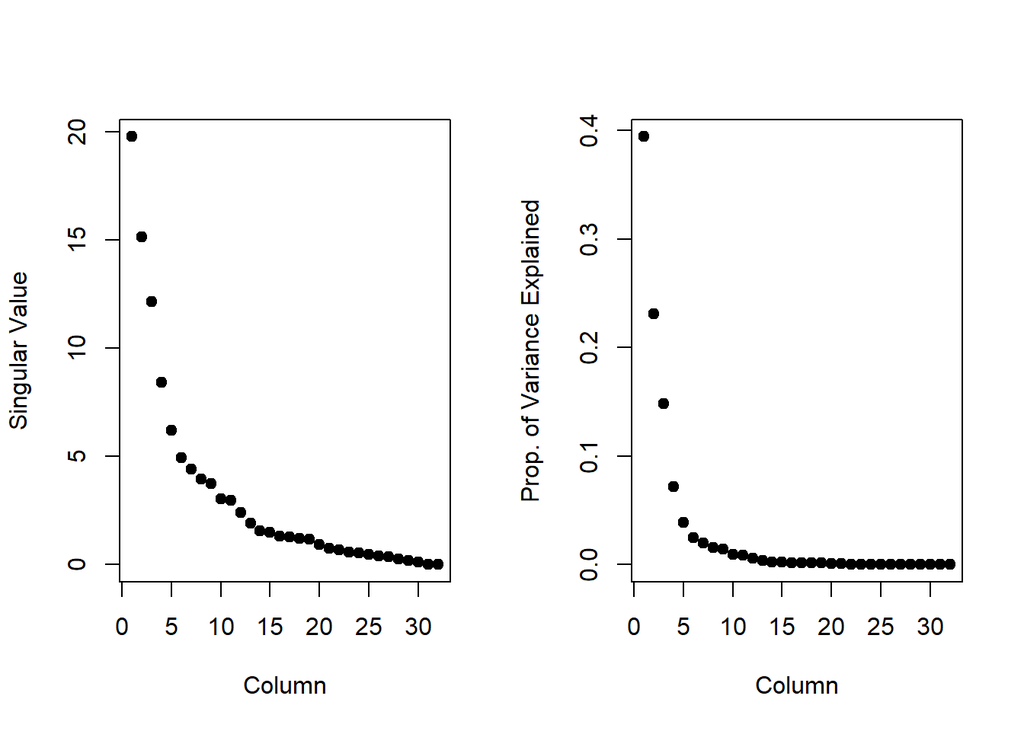

```r
par(mfrow = c(1,2))

plot(svd_face$d, xlab = "Column" , ylab = "Singular Value", pch = 19)

plot(svd_face$d^2/sum(svd_face$d^2), xlab = "Column", ylab = "Prop. of Variance Explained", pch =19)
```

##### Explanation:

- So 40% of the variation in the data matrix is explained by the first component, 22% by the second, and so forth.
- It looks like most of the variation is contained in the first 10 components.

#### 5.1.4 Can we try to create an approximate image using only a few components?

- Suppose we create the product of pieces of these, say the first columns of U and V and the first element of D.
- The first column of U can be interpreted as a 32 by 1 matrix (recall that faceData was a 32 by 32 matrix), so we can multiply it by the first element of D, a 1 by 1 matrix, and get a 32 by 1 matrix result.
- We can multiply that by the transpose of the first column of V, which is the first principal component. (We have to use the transpose of V’s column to make it a 1 by 32 matrix in order to do the matrix multiplication properly.)

#### 5.1.4.1 Using only 1st Column

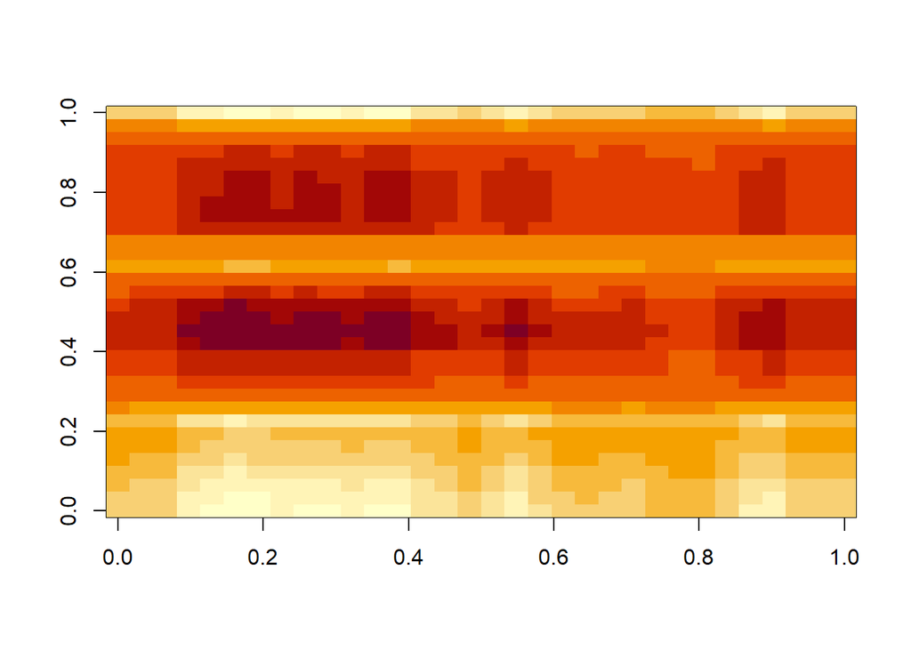

```r
face_compress1 <- (svd_face$u[,1] * svd_face$d[1]) %*% t(svd_face$v[,1])

image(t(face_compress1)[,nrow(face_compress1):1])
```

##### Explanation:

- It might not look like much but it’s a good start.

#### 5.1.4.2 Using 1st and 2nd Columns

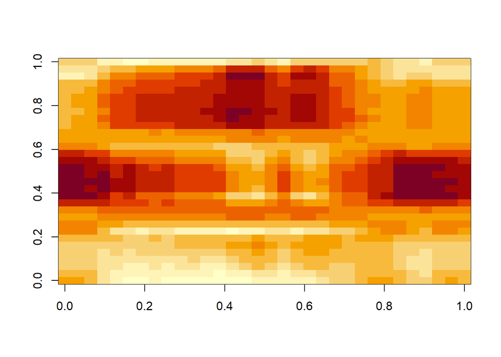

```r
face_compress2 <- svd_face$u[,1:2] %*% diag(svd_face$d[1:2]) %*% t(svd_face$v[,1:2])

image(t(face_compress2)[,nrow(face_compress2):1])
```

##### Explanation:

- We’re starting to see slightly more detail, and maybe if you squint you see a grimacing mouth.

#### 5.1.4.3 Using 5 Columns

- Now let’s see what image results using 5 components.
- From our plot of the variance explained 5 components covered a sizeable percentage of the variation.

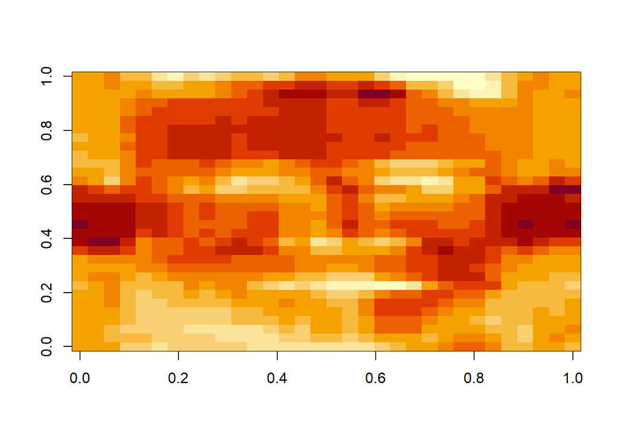

```r
face_compress3 <- svd_face$u[,1:5] %*% diag(svd_face$d[1:5]) %*% t(svd_face$v[,1:5])

image(t(face_compress3)[,nrow(face_compress3):1])
```

##### Explanation:

- Certainly much better.
- Clearly a face is appearing with eyes, nose, ears, and mouth recognizable.

#### 5.1.4.4 Using 10 Columns

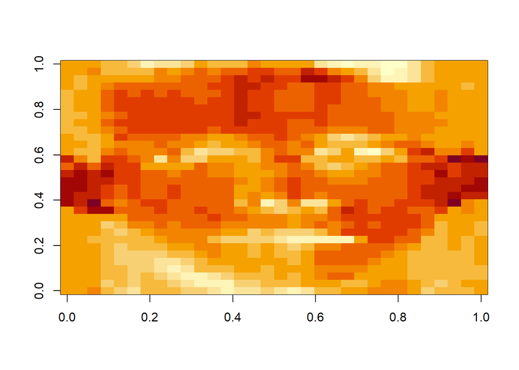

```r
face_compress4 <- svd_face$u[,1:10] %*% diag(svd_face$d[1:10]) %*% t(svd_face$v[,1:10])

image(t(face_compress4)[,nrow(face_compress4):1])
```

##### Explanation:

- Now that’s pretty close to the original which was low resolution to begin with, but you can see that 10 components really do capture the essence of the image.
- Singular value decomposition is a good way to approximate data without having to store a lot.

## 6. Important Points to Remember

1. When reducing dimensions you have to pay attention to the scales on which different variables are measured and make sure that all your data is in consistent units.
- In other words, scales of your data matter.
2. Principal components and singular values may mix real patterns, as we saw in our simple 2-pattern example, so finding and separating out the real patterns require some detective work.